# Confirmatory Factor Analysis and SEM

Back to schedule

```r
library(mosaic)
library(ggplot2)
library(dplyr)
library(psych)
```

```r
#install.packages("lavaan")
library(lavaan)

#install.packages("semPlot")
library(semPlot)
```

# Confirmatory Factor Analysis

Now, instead of taking a shot in the dark about the factor structure, we are going in with a clear idea about which items we things load on which factors. Our goal is to test how well our model of the factor structure actually fits the data.

First we specify the model.

```r
bf_model <- ' agreeable =~ A1 + A2 + A3 + A4 + A5
              conscient =~ C1 + C2 + C3 + C4 + C5
              extrov =~ E1 + E2 + E3 + E4 + E5
              neurot =~ N1 + N2 + N3 + N4 + N5
              openness =~ O1 + O2 + O3 + O4 + O5 '
```

## Diagram

Plot the model to make sure it is what you want. Here we are using the `semPaths()` and `semPlotModel()` from the `semPlot` package. The `rotation = 2` option forces the exogenous variables to be on the left side.

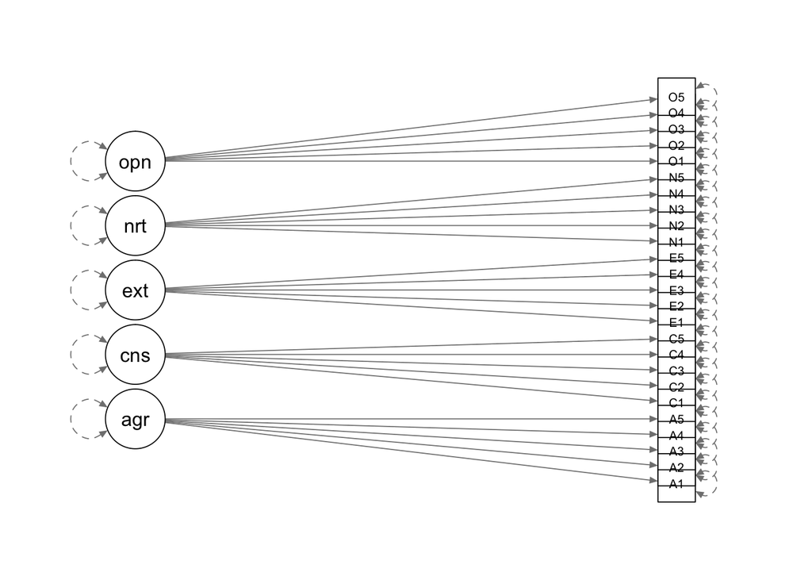

```r
semPaths(semPlotModel(bf_model), rotation = 2)
```

## Output

Then fit the CFA model with `cfa()` and ask for the relevant output.

```r
bf_fit <- cfa(bf_model, data = bfi)

summary(bf_fit, fit.measures = TRUE, rsq=TRUE)
```

```
## lavaan (0.5-23.1097) converged normally after  55 iterations
##
##                                                   Used       Total
##   Number of observations                          2436        2800
##
##   Estimator                                         ML
##   Minimum Function Test Statistic             4165.467
##   Degrees of freedom                               265
##   P-value (Chi-square)                           0.000
##
## Model test baseline model:
##
##   Minimum Function Test Statistic            18222.116
##   Degrees of freedom                               300
##   P-value                                        0.000
##
## User model versus baseline model:
##
##   Comparative Fit Index (CFI)                    0.782
##   Tucker-Lewis Index (TLI)                       0.754
##
## Loglikelihood and Information Criteria:
##
##   Loglikelihood user model (H0)             -99840.238
##   Loglikelihood unrestricted model (H1)     -97757.504
##
##   Number of free parameters                         60
##   Akaike (AIC)                              199800.476
##   Bayesian (BIC)                            200148.363
##   Sample-size adjusted Bayesian (BIC)       199957.729
##
## Root Mean Square Error of Approximation:
##
##   RMSEA                                          0.078
##   90 Percent Confidence Interval          0.076  0.080
##   P-value RMSEA <= 0.05                          0.000
##
## Standardized Root Mean Square Residual:
##
##   SRMR                                           0.075
```

[output cut: 101 more lines]

```
##     E1                0.318
##     E2                0.488
##     E3                0.393
##     E4                0.494
##     E5                0.306
##     N1                0.680
##     N2                0.644
##     N3                0.519
##     N4                0.328
##     N5                0.253
##     O1                0.318
##     O2                0.174
##     O3                0.524
##     O4                0.054
##     O5                0.212
```

```r
inspect(bf_fit, what = "std") #for standardized estimates
```

```
## $lambda
##    agrebl cnscnt extrov neurot opnnss
## A1  0.344  0.000  0.000  0.000  0.000
## A2 -0.648  0.000  0.000  0.000  0.000
## A3 -0.749  0.000  0.000  0.000  0.000
## A4 -0.510  0.000  0.000  0.000  0.000
## A5 -0.687  0.000  0.000  0.000  0.000
## C1  0.000  0.551  0.000  0.000  0.000
## C2  0.000  0.592  0.000  0.000  0.000
## C3  0.000  0.546  0.000  0.000  0.000
## C4  0.000 -0.702  0.000  0.000  0.000
## C5  0.000 -0.620  0.000  0.000  0.000
## E1  0.000  0.000  0.564  0.000  0.000
## E2  0.000  0.000  0.699  0.000  0.000
## E3  0.000  0.000 -0.627  0.000  0.000
## E4  0.000  0.000 -0.703  0.000  0.000
## E5  0.000  0.000 -0.553  0.000  0.000
## N1  0.000  0.000  0.000  0.825  0.000
## N2  0.000  0.000  0.000  0.803  0.000
## N3  0.000  0.000  0.000  0.721  0.000
## N4  0.000  0.000  0.000  0.573  0.000
## N5  0.000  0.000  0.000  0.503  0.000
## O1  0.000  0.000  0.000  0.000  0.564
## O2  0.000  0.000  0.000  0.000 -0.418
## O3  0.000  0.000  0.000  0.000  0.724
## O4  0.000  0.000  0.000  0.000  0.233
## O5  0.000  0.000  0.000  0.000 -0.461
##
## $theta
##    A1    A2    A3    A4    A5    C1    C2    C3    C4    C5    E1    E2
## A1 0.882
## A2 0.000 0.580
## A3 0.000 0.000 0.438
## A4 0.000 0.000 0.000 0.740
## A5 0.000 0.000 0.000 0.000 0.528
## C1 0.000 0.000 0.000 0.000 0.000 0.697
## C2 0.000 0.000 0.000 0.000 0.000 0.000 0.650
## C3 0.000 0.000 0.000 0.000 0.000 0.000 0.000 0.702
## C4 0.000 0.000 0.000 0.000 0.000 0.000 0.000 0.000 0.507
## C5 0.000 0.000 0.000 0.000 0.000 0.000 0.000 0.000 0.000 0.615
```

[output cut: 60 more lines]

```
## N4
## N5
## O1
## O2
## O3
## O4
## O5 0.788
##
## $psi
##           agrebl cnscnt extrov neurot opnnss
## agreeable  1.000
## conscient -0.334  1.000
## extrov     0.683 -0.357  1.000
## neurot     0.223 -0.283  0.244  1.000
## openness  -0.303  0.301 -0.453 -0.112  1.000
```

## Modification Indicies

Because our model is not a great fit to our data, we might want to ask for the *modification indicies* with the `modindices()` function. `lavaan` will give you a set of changes you can make that will increase the fit on the model. The `mi` value is the amount a reduction in the chi-square statistics that each change would bring—so the higher the better because a reduction in chi-square means and increase in fit!

```r
modindices(bf_fit) %>%
  arrange(desc(mi)) %>%
  select(lhs, op, rhs, mi) %>%
  head(10)
```

```
##          lhs op rhs       mi
## 1         N1 ~~  N2 418.8124
## 2     extrov =~  N4 200.7898
## 3   openness =~  E3 153.7152
## 4         N3 ~~  N4 134.1036
## 5   openness =~  E4 122.5581
## 6  conscient =~  E5 121.4990
## 7     extrov =~  O3 114.2021
## 8     extrov =~  O4 113.8627
## 9     neurot =~  C5 108.7538
## 10    extrov =~  A5 108.5874
```

```r
?bfi
```

## Re-specifying the Model

Maybe we want to add error covariances based on modification indices. I recommend only doing this if it makes theoretical sense. Also, what ever theoretical rule you use to justify making these error correlations, if it applies to other sets of items, then add the correlations there too. Be consistent! **If you just make changes based on the modification indicies without thinking carefully about the theory behind them, then you are doing exploratory factor analysis.**

```r
bf_model_re1 <- ' agreeable =~ A1 + A2 + A3 + A4 + A5
                  conscient =~ C1 + C2 + C3 + C4 + C5
                  extrov =~ E1 + E2 + E3 + E4 + E5
                  neurot =~ N1 + N2 + N3 + N4 + N5
                  openness =~ O1 + O2 + O3 + O4 + O5

                  N1 ~~ N2
                  N3 ~~ N4'

bf_model_re1.1 <- ' agreeable =~ A1 + A2 + A3 + A4 + A5
                  conscient =~ C1 + C2 + C3 + C4 + C5
                  extrov =~ E1 + E2 + E3 + E4 + E5
                  anx =~ N1 + N2
                  dep =~ N3 + N4
                  neurot =~ anx + dep + N5
                  openness =~ O1 + O2 + O3 + O4 + O5 '
```

How would you ask for a diagram of this model?

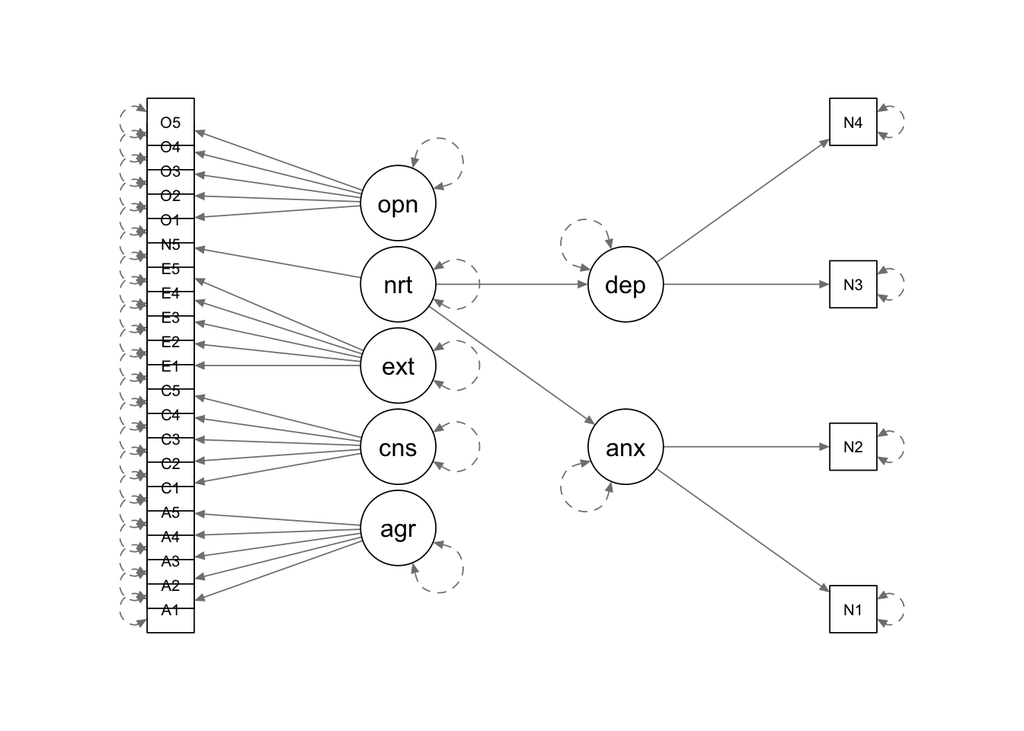

```r
semPaths(semPlotModel(bf_model_re1.1), rotation = 2)
```

```r
bf_fit_re1 <- cfa(bf_model_re1, data = bfi)

summary(bf_fit_re1, fit.measures = TRUE, rsq=TRUE)
```

```
## lavaan (0.5-23.1097) converged normally after  57 iterations
##
##                                                   Used       Total
##   Number of observations                          2436        2800
##
##   Estimator                                         ML
##   Minimum Function Test Statistic             3808.150
##   Degrees of freedom                               263
##   P-value (Chi-square)                           0.000
##
## Model test baseline model:
##
##   Minimum Function Test Statistic            18222.116
##   Degrees of freedom                               300
##   P-value                                        0.000
##
## User model versus baseline model:
##
##   Comparative Fit Index (CFI)                    0.802
##   Tucker-Lewis Index (TLI)                       0.774
##
## Loglikelihood and Information Criteria:
##
##   Loglikelihood user model (H0)             -99661.580
##   Loglikelihood unrestricted model (H1)     -97757.504
##
##   Number of free parameters                         62
##   Akaike (AIC)                              199447.159
##   Bayesian (BIC)                            199806.642
##   Sample-size adjusted Bayesian (BIC)       199609.654
##
## Root Mean Square Error of Approximation:
##
##   RMSEA                                          0.074
##   90 Percent Confidence Interval          0.072  0.076
##   P-value RMSEA <= 0.05                          0.000
##
## Standardized Root Mean Square Residual:
##
##   SRMR                                           0.073
```

[output cut: 105 more lines]

```
##     E1                0.319
##     E2                0.497
##     E3                0.386
##     E4                0.495
##     E5                0.305
##     N1                0.430
##     N2                0.399
##     N3                0.668
##     N4                0.498
##     N5                0.301
##     O1                0.318
##     O2                0.173
##     O3                0.526
##     O4                0.055
##     O5                0.211
```

```r
inspect(bf_fit_re1, what = "std")
```

```
## $lambda
##    agrebl cnscnt extrov neurot opnnss
## A1  0.343  0.000  0.000  0.000  0.000
## A2 -0.650  0.000  0.000  0.000  0.000
## A3 -0.752  0.000  0.000  0.000  0.000
## A4 -0.510  0.000  0.000  0.000  0.000
## A5 -0.683  0.000  0.000  0.000  0.000
## C1  0.000  0.546  0.000  0.000  0.000
## C2  0.000  0.587  0.000  0.000  0.000
## C3  0.000  0.545  0.000  0.000  0.000
## C4  0.000 -0.706  0.000  0.000  0.000
## C5  0.000 -0.625  0.000  0.000  0.000
## E1  0.000  0.000  0.565  0.000  0.000
## E2  0.000  0.000  0.705  0.000  0.000
## E3  0.000  0.000 -0.621  0.000  0.000
## E4  0.000  0.000 -0.704  0.000  0.000
## E5  0.000  0.000 -0.552  0.000  0.000
## N1  0.000  0.000  0.000  0.656  0.000
## N2  0.000  0.000  0.000  0.631  0.000
## N3  0.000  0.000  0.000  0.818  0.000
## N4  0.000  0.000  0.000  0.705  0.000
## N5  0.000  0.000  0.000  0.548  0.000
## O1  0.000  0.000  0.000  0.000  0.564
## O2  0.000  0.000  0.000  0.000 -0.416
## O3  0.000  0.000  0.000  0.000  0.725
## O4  0.000  0.000  0.000  0.000  0.235
## O5  0.000  0.000  0.000  0.000 -0.460
##
## $theta
##    A1     A2     A3     A4     A5     C1     C2     C3     C4     C5
## A1  0.883
## A2  0.000  0.577
## A3  0.000  0.000  0.434
## A4  0.000  0.000  0.000  0.740
## A5  0.000  0.000  0.000  0.000  0.533
## C1  0.000  0.000  0.000  0.000  0.000  0.702
## C2  0.000  0.000  0.000  0.000  0.000  0.000  0.656
## C3  0.000  0.000  0.000  0.000  0.000  0.000  0.000  0.703
## C4  0.000  0.000  0.000  0.000  0.000  0.000  0.000  0.000  0.501
## C5  0.000  0.000  0.000  0.000  0.000  0.000  0.000  0.000  0.000  0.610
```

[output cut: 60 more lines]

```
## N4
## N5
## O1  0.682
## O2  0.000  0.827
## O3  0.000  0.000  0.474
## O4  0.000  0.000  0.000  0.945
## O5  0.000  0.000  0.000  0.000  0.789
##
## $psi
##           agrebl cnscnt extrov neurot opnnss
## agreeable  1.000
## conscient -0.333  1.000
## extrov     0.680 -0.358  1.000
## neurot     0.204 -0.315  0.313  1.000
## openness  -0.304  0.299 -0.451 -0.110  1.000
```

```r
modindices(bf_fit_re1) %>%
  arrange(desc(mi)) %>%
  select(lhs, op, rhs, mi) %>%
  head(10)
```

```
##          lhs op rhs       mi
## 1   openness =~  E3 160.1243
## 2     extrov =~  N4 157.7845
## 3     neurot =~  O4 146.2368
## 4     neurot =~  C5 135.1787
## 5     neurot =~  C2 131.4783
## 6  conscient =~  E5 124.7340
## 7     extrov =~  O4 123.9378
## 8   openness =~  E4 119.2854
## 9     extrov =~  A5 117.0221
## 10        C1 ~~  C2 113.4368
```

We might also want to remove A1 – “Am indifferent to the feelings of others,” and O4 – “Spend time reflecting on things,” based on crappy loadings.

```r
bf_model_re2 <- ' agreeable =~ A2 + A3 + A4 + A5
                  conscient =~ C1 + C2 + C3 + C4 + C5
                  extrov =~ E1 + E2 + E3 + E4 + E5
                  neurot =~ N1 + N2 + N3 + N4 + N5
                  openness =~ O1 + O2 + O3 + O5

                  N1 ~~ N2
                  N3 ~~ N4'

bf_fit_re2 <- cfa(bf_model_re2, data = bfi)

summary(bf_fit_re2, fit.measures = TRUE, rsq=TRUE)
```

```
## lavaan (0.5-23.1097) converged normally after  51 iterations
##
##                                                   Used       Total
##   Number of observations                          2454        2800
##
##   Estimator                                         ML
##   Minimum Function Test Statistic             3145.804
##   Degrees of freedom                               218
##   P-value (Chi-square)                           0.000
##
## Model test baseline model:
##
##   Minimum Function Test Statistic            17305.746
##   Degrees of freedom                               253
##   P-value                                        0.000
##
## User model versus baseline model:
##
##   Comparative Fit Index (CFI)                    0.828
##   Tucker-Lewis Index (TLI)                       0.801
##
## Loglikelihood and Information Criteria:
##
##   Loglikelihood user model (H0)             -92351.755
##   Loglikelihood unrestricted model (H1)     -90778.853
##
##   Number of free parameters                         58
##   Akaike (AIC)                              184819.510
##   Bayesian (BIC)                            185156.227
##   Sample-size adjusted Bayesian (BIC)       184971.947
##
## Root Mean Square Error of Approximation:
##
##   RMSEA                                          0.074
##   90 Percent Confidence Interval          0.072  0.076
##   P-value RMSEA <= 0.05                          0.000
##
## Standardized Root Mean Square Residual:
##
##   SRMR                                           0.068
```

[output cut: 99 more lines]

```
##     C5                0.389
##     E1                0.315
##     E2                0.493
##     E3                0.392
##     E4                0.497
##     E5                0.307
##     N1                0.427
##     N2                0.402
##     N3                0.666
##     N4                0.492
##     N5                0.302
##     O1                0.311
##     O2                0.173
##     O3                0.523
##     O5                0.200
```

```r
inspect(bf_fit_re2, what = "std")
```

```
## $lambda
##    agrebl cnscnt extrov neurot opnnss
## A2  0.627  0.000  0.000  0.000  0.000
## A3  0.744  0.000  0.000  0.000  0.000
## A4  0.510  0.000  0.000  0.000  0.000
## A5  0.696  0.000  0.000  0.000  0.000
## C1  0.000  0.547  0.000  0.000  0.000
## C2  0.000  0.588  0.000  0.000  0.000
## C3  0.000  0.546  0.000  0.000  0.000
## C4  0.000 -0.705  0.000  0.000  0.000
## C5  0.000 -0.623  0.000  0.000  0.000
## E1  0.000  0.000  0.561  0.000  0.000
## E2  0.000  0.000  0.702  0.000  0.000
## E3  0.000  0.000 -0.626  0.000  0.000
## E4  0.000  0.000 -0.705  0.000  0.000
## E5  0.000  0.000 -0.554  0.000  0.000
## N1  0.000  0.000  0.000  0.653  0.000
## N2  0.000  0.000  0.000  0.634  0.000
## N3  0.000  0.000  0.000  0.816  0.000
## N4  0.000  0.000  0.000  0.701  0.000
## N5  0.000  0.000  0.000  0.550  0.000
## O1  0.000  0.000  0.000  0.000  0.558
## O2  0.000  0.000  0.000  0.000 -0.416
## O3  0.000  0.000  0.000  0.000  0.723
## O5  0.000  0.000  0.000  0.000 -0.447
##
## $theta
##    A2     A3     A4     A5     C1     C2     C3     C4     C5     E1
## A2  0.607
## A3  0.000  0.447
## A4  0.000  0.000  0.740
## A5  0.000  0.000  0.000  0.515
## C1  0.000  0.000  0.000  0.000  0.701
## C2  0.000  0.000  0.000  0.000  0.000  0.654
## C3  0.000  0.000  0.000  0.000  0.000  0.000  0.702
## C4  0.000  0.000  0.000  0.000  0.000  0.000  0.000  0.503
## C5  0.000  0.000  0.000  0.000  0.000  0.000  0.000  0.000  0.611
## E1  0.000  0.000  0.000  0.000  0.000  0.000  0.000  0.000  0.000  0.685
## E2  0.000  0.000  0.000  0.000  0.000  0.000  0.000  0.000  0.000  0.000
## E3  0.000  0.000  0.000  0.000  0.000  0.000  0.000  0.000  0.000  0.000
```

[output cut: 52 more lines]

```
## N3
## N4
## N5
## O1
## O2  0.827
## O3  0.000  0.477
## O5  0.000  0.000  0.800
##
## $psi
##           agrebl cnscnt extrov neurot opnnss
## agreeable  1.000
## conscient  0.343  1.000
## extrov    -0.702 -0.352  1.000
## neurot    -0.208 -0.311  0.314  1.000
## openness   0.310  0.309 -0.483 -0.139  1.000
```

It is still not a great fit to the data, but I don’t think I’d want to make any of these modifications.

```r
modindices(bf_fit_re2) %>%
  arrange(desc(mi)) %>%
  select(lhs, op, rhs, mi) %>%
  head(10)
```

```
##          lhs op rhs        mi
## 1     extrov =~  N4 160.70218
## 2   openness =~  E3 140.06928
## 3     neurot =~  C5 135.79120
## 4   openness =~  E4 129.60464
## 5     neurot =~  C2 128.91871
## 6  conscient =~  E5 127.34527
## 7         C1 ~~  C2 110.30471
## 8         O2 ~~  O5  98.82617
## 9     extrov =~  A5  89.36109
## 10    extrov =~  N3  87.78938
```

We can compare the CFIs for the 3 models with the `fitmeasures()` function.

```r
fitmeasures(bf_fit)[9]
```

```
##       cfi
## 0.7823657
```

```r
fitmeasures(bf_fit_re1)[9]
```

```
##       cfi
## 0.8021913
```

```r
fitmeasures(bf_fit_re2)[9]
```

```
##       cfi
## 0.8283089
```

# Structural Equation Modeling

In real life you should not proceed to the structural equation modeling phase unless you have a good fitting measurement model (CFA). For demonstration purposes let’s add gender, age, and education into the model as predictors of the 5 personality factors.

```r
bf_model_sem <- ' agreeable =~ A2 + A3 + A4 + A5
                  conscient =~ C1 + C2 + C3 + C4 + C5
                  extrov =~ E1 + E2 + E3 + E4 + E5
                  neurot =~ N1 + N2 + N3 + N4 + N5
                  openness =~ O1 + O2 + O3 + O5

                  N1 ~~ N2
                  N3 ~~ N4

                  agreeable ~ age + gender + education
                  conscient ~ age + gender + education
                  extrov ~ age + gender + education
                  neurot ~ age + gender + education
                  openness ~ age + gender + education

                  age ~~ gender
                  age ~~ education
                  gender ~~ education
                  '
```

Let’s make the graph.

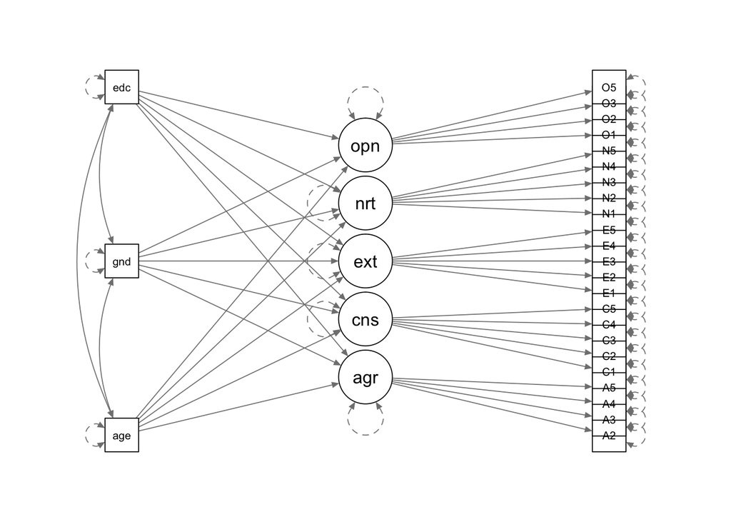

```r
semPaths(semPlotModel(bf_model_sem), rotation = 2)
```

Instead of the `cfa()` function we will use the `sem()` function.

```r
bf_fit_sem <- sem(bf_model_sem, data = bfi)

summary(bf_fit_sem, fit.measures = TRUE, rsq=TRUE)
```

```
## lavaan (0.5-23.1097) converged normally after  91 iterations
##
##                                                   Used       Total
##   Number of observations                          2253        2800
##
##   Estimator                                         ML
##   Minimum Function Test Statistic             3288.796
##   Degrees of freedom                               272
##   P-value (Chi-square)                           0.000
##
## Model test baseline model:
##
##   Minimum Function Test Statistic            16549.044
##   Degrees of freedom                               325
##   P-value                                        0.000
##
## User model versus baseline model:
##
##   Comparative Fit Index (CFI)                    0.814
##   Tucker-Lewis Index (TLI)                       0.778
##
## Loglikelihood and Information Criteria:
##
##   Loglikelihood user model (H0)             -97728.434
##   Loglikelihood unrestricted model (H1)     -96084.035
##
##   Number of free parameters                         79
##   Akaike (AIC)                              195614.867
##   Bayesian (BIC)                            196066.749
##   Sample-size adjusted Bayesian (BIC)       195815.753
##
## Root Mean Square Error of Approximation:
##
##   RMSEA                                          0.070
##   90 Percent Confidence Interval          0.068  0.072
##   P-value RMSEA <= 0.05                          0.000
##
## Standardized Root Mean Square Residual:
##
##   SRMR                                           0.064
```

[output cut: 135 more lines]

```
##     E5                0.314
##     N1                0.442
##     N2                0.417
##     N3                0.643
##     N4                0.442
##     N5                0.323
##     O1                0.317
##     O2                0.180
##     O3                0.518
##     O5                0.209
##     agreeable         0.066
##     conscient         0.023
##     extrov            0.022
##     neurot            0.031
##     openness          0.028
```

```r
#standardized item loadings
inspect(bf_fit_sem, what = "std")$lambda
```

```
##           agrebl cnscnt extrov neurot opnnss age gender eductn
## A2         0.622  0.000  0.000  0.000  0.000   0      0      0
## A3         0.730  0.000  0.000  0.000  0.000   0      0      0
## A4         0.507  0.000  0.000  0.000  0.000   0      0      0
## A5         0.683  0.000  0.000  0.000  0.000   0      0      0
## C1         0.000  0.530  0.000  0.000  0.000   0      0      0
## C2         0.000  0.570  0.000  0.000  0.000   0      0      0
## C3         0.000  0.547  0.000  0.000  0.000   0      0      0
## C4         0.000 -0.705  0.000  0.000  0.000   0      0      0
## C5         0.000 -0.628  0.000  0.000  0.000   0      0      0
## E1         0.000  0.000  0.560  0.000  0.000   0      0      0
## E2         0.000  0.000  0.695  0.000  0.000   0      0      0
## E3         0.000  0.000 -0.644  0.000  0.000   0      0      0
## E4         0.000  0.000 -0.707  0.000  0.000   0      0      0
## E5         0.000  0.000 -0.561  0.000  0.000   0      0      0
## N1         0.000  0.000  0.000  0.665  0.000   0      0      0
## N2         0.000  0.000  0.000  0.646  0.000   0      0      0
## N3         0.000  0.000  0.000  0.802  0.000   0      0      0
## N4         0.000  0.000  0.000  0.665  0.000   0      0      0
## N5         0.000  0.000  0.000  0.568  0.000   0      0      0
## O1         0.000  0.000  0.000  0.000  0.563   0      0      0
## O2         0.000  0.000  0.000  0.000 -0.425   0      0      0
## O3         0.000  0.000  0.000  0.000  0.719   0      0      0
## O5         0.000  0.000  0.000  0.000 -0.457   0      0      0
## age        0.000  0.000  0.000  0.000  0.000   1      0      0
## gender     0.000  0.000  0.000  0.000  0.000   0      1      0
## education  0.000  0.000  0.000  0.000  0.000   0      0      1
```

```r
#standardized path estimates
inspect(bf_fit_sem, what = "std")$beta
```

```
##           agrebl cnscnt extrov neurot opnnss    age gender eductn
## agreeable      0      0      0      0      0  0.117  0.224 -0.017
## conscient      0      0      0      0      0  0.113  0.094  0.004
## extrov         0      0      0      0      0 -0.053 -0.136  0.002
## neurot         0      0      0      0      0 -0.122  0.129 -0.018
## openness       0      0      0      0      0  0.049 -0.103  0.114
## age            0      0      0      0      0  0.000  0.000  0.000
## gender         0      0      0      0      0  0.000  0.000  0.000
## education      0      0      0      0      0  0.000  0.000  0.000
```

```r
#correlations bewteen latent variables and exogenous variables
inspect(bf_fit_sem, what = "std")$psi
```

```
##           agrebl cnscnt extrov neurot opnnss age    gender eductn
## agreeable  0.934
## conscient  0.316  0.977
## extrov    -0.705 -0.342  0.978
## neurot    -0.219 -0.317  0.317  0.969
## openness   0.304  0.302 -0.502 -0.131  0.972
## age        0.000  0.000  0.000  0.000  0.000  1.000
## gender     0.000  0.000  0.000  0.000  0.000  0.047  1.000
## education  0.000  0.000  0.000  0.000  0.000  0.248  0.008  1.000
```

Back to schedule